# ResIN R Workshop SPSP 2023

2023-01-29

# Teaser

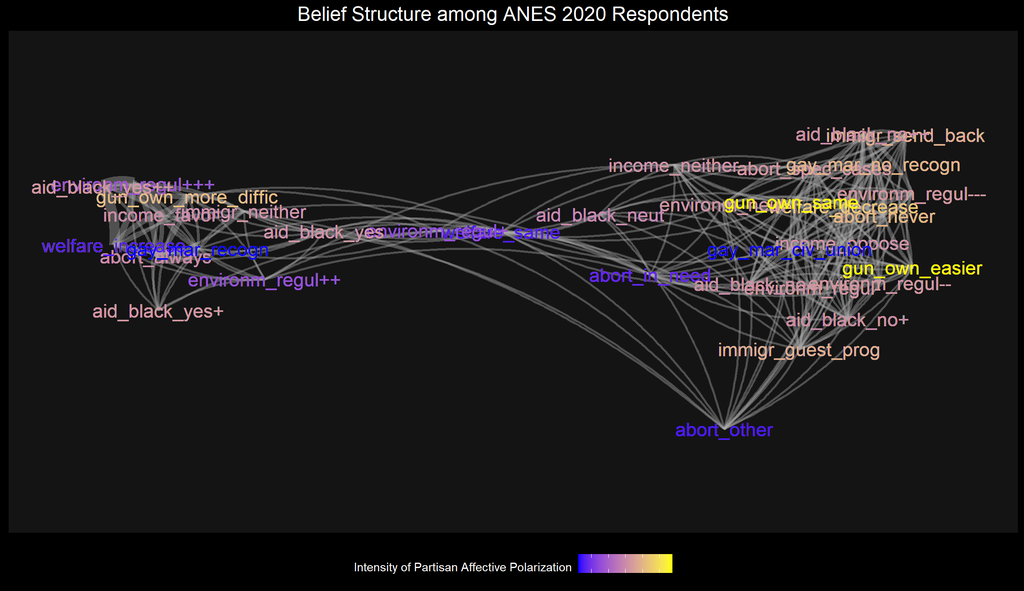

# Workshop contents

1. **Data preparation & cleaning**
2. **Main algorithm**
3. **Visualization**
4. **Canned ResIn functions & glimpse at capabilities of future package**

# Workshop prerequisites

```r
rm(list = setdiff(ls(), lsf.str())) ## To erase memory

## Loading required packages
if(!require("pacman")) install.packages('pacman')
library(pacman)
p_load(tidyverse)
p_load(igraph)
p_load(qgraph)
p_load(fastDummies)
p_load(Matrix)
p_load(knitr)
p_load(rgexf)
p_load(plotly)
p_load(htmlwidgets)
p_load(visNetwork)

## 2020 Wave of the ANES as example data
anes_timeseries_2020 <- read.csv("anes_timeseries_2020.csv")

## For reproducibility
set.seed(42)
```

# 1. Data preparation & cleaning

- Select items for ResIN network and optional co-variates
- Clean data
  - **ResIN node variables**: Character, factor, or numeric are accepted. Be sure to categorize continuous variables beforehand and to apply uniform coding within each variable. ResIn handles character lables for numeric values very well - this feature is useful for visualization
  - **Co-variates** should be numeric
  - **NA’s**: Apply a uniform code for all
  - Non-monotonic Likert scale items do not need to be recoded <3

# 1.1 Data preparation - before

| V200002 | V200003 | V200004 | V200005 | V200006 | V200007 | V200008 | V200009 |
| --- | --- | --- | --- | --- | --- | --- | --- |
| 3 | 2 | 3 | 0 | -2 | -2 | -2 | 0 |
| 3 | 2 | 3 | 0 | 4 | -1 | 3 | 0 |
| 3 | 2 | 3 | 0 | -2 | -2 | -2 | 0 |
| 3 | 2 | 3 | 0 | -2 | -2 | -2 | 0 |
| 3 | 2 | 3 | 1 | -2 | -2 | -2 | 0 |
| 3 | 2 | 3 | 0 | -2 | -2 | -2 | 0 |
| 3 | 2 | 3 | 0 | -2 | -2 | -2 | 0 |
| 3 | 2 | 3 | 0 | -2 | -2 | -2 | 0 |
| 3 | 2 | 3 | 0 | -2 | -2 | -2 | 0 |
| 3 | 2 | 3 | 1 | 4 | -1 | 3 | 0 |
| 3 | 2 | 3 | 0 | -2 | -2 | -2 | 0 |
| 3 | 2 | 3 | 0 | -2 | -2 | -2 | 0 |
| 3 | 2 | 3 | 1 | 4 | -1 | 3 | 0 |

# 1.2 Data preparation - recode missing

```r
## Selecting Res-IN node variables:
anes_nodes <- dplyr::select(anes_timeseries_2020, c("V201336", "V202257",
                                                    "V201417", "V201312",
                                                    "V201416", "V201262",
                                                    "V202337", "V201258"))

## Recoding missing values (check ANES codebook!)
anes_nodes$V201336[anes_nodes$V201336 %in% c(-9, -8, -7, -6, -5, 99)] <- NA
anes_nodes$V202257[anes_nodes$V202257 %in% c(-9, -8, -7, -6, -5, 99)] <- NA
anes_nodes$V201417[anes_nodes$V201417 %in% c(-9, -8, -7, -6, -5, 99)] <- NA
anes_nodes$V201312[anes_nodes$V201312 %in% c(-9, -8, -7, -6, -5, 99)] <- NA
anes_nodes$V201416[anes_nodes$V201416 %in% c(-9, -8, -7, -6, -5, 99)] <- NA
anes_nodes$V201262[anes_nodes$V201262 %in% c(-9, -8, -7, -6, -5, 99)] <- NA
anes_nodes$V202337[anes_nodes$V202337 %in% c(-9, -8, -7, -6, -5, 99)] <- NA
anes_nodes$V201258[anes_nodes$V201258 %in% c(-9, -8, -7, -6, -5, 99)] <- NA

## Give more recognizable names
colnames(anes_nodes) <- c("abort", "income", "immigr", "welfare", "gay_mar",
                          "environm", "gun_own", "aid_black")
```

# 1.4 Data preparation - adding lables

```r
## Re-code response labels to make them more recognizable
anes_nodes <- anes_nodes %>% mutate(
                  abort = recode(abort, `1` = "never",
                                        `2` = "spec_cases",
                                        `3` = "in_need",
                                        `4` = "always",
                                        `5` = "other"),

  income = recode(income, `1` = "favor",`2` = "oppose", `3` = "neither"),
  immigr = recode(immigr, `1` = "send_back", `2` = "guest_prog",`3` = "neither"),
  welfare = recode(welfare, `1` = "increase",`2` = "decrease", `3` = "same",),
  gay_mar = recode(gay_mar, `1` = "recogn",`2` = "civ_union", `3` = "no_recogn"),
  environm = recode(environm, `1` = "regul+++",`2` = "regul++", `3` = "regul+", `4` = "neut",`5` = "regul-", `6` = "regul--", `7` = "regul---"),
  gun_own = recode(gun_own, `1` = "more_diffic",`2` = "easier", `3` = "same"),
  aid_black = recode(aid_black, `1` = "yes++",`2` = "yes+", `3` = "yes", `4` = "neut",`5` = "no", `6` = "no+", `7` = "no++"))
```

# 1.5 Data preparation - after

| abort | income | immigr | welfare | gay_mar | environm | gun_own | aid_black |
| --- | --- | --- | --- | --- | --- | --- | --- |
| spec_cases | favor | send_back | decrease | no_recogn | regul— | same | no++ |
| always | neither | neither | decrease | recogn | NA | same | neut |
| always | favor | NA | increase | recogn | regul+++ | more_diffic | yes |
| never | favor | send_back | same | recogn | regul+++ | same | NA |
| in_need | neither | guest_prog | same | civ_union | neut | same | no+ |
| always | neither | neither | same | recogn | NA | more_diffic | yes |
| in_need | neither | guest_prog | increase | recogn | regul- | more_diffic | no++ |
| always | neither | send_back | same | no_recogn | NA | more_diffic | no++ |
| always | neither | send_back | same | recogn | NA | more_diffic | NA |
| always | neither | guest_prog | same | civ_union | NA | easier | neut |
| never | neither | neither | increase | no_recogn | regul+++ | more_diffic | yes++ |
| spec_cases | oppose | neither | same | recogn | regul+++ | more_diffic | no++ |
| always | neither | send_back | increase | civ_union | neut | more_diffic | no++ |
| always | favor | neither | same | recogn | regul+++ | more_diffic | yes |
| always | oppose | guest_prog | same | civ_union | NA | more_diffic | yes++ |
| in_need | neither | neither | same | recogn | NA | easier | neut |
| always | favor | neither | same | recogn | regul+ | same | neut |
| always | favor | neither | same | recogn | regul+ | more_diffic | yes |

# 2. Main Res-IN algorithim

2.1 Item binarization

2.2 Res-In adjacency matrix

2.3 Force-directed location estimation

2.4 Coordinate rotation (PCA)

# 2.1.1 Item binarization

- Expand original data-set into dummy variables for each possible item response
- Results in $n$ by $\sum_{l}k$ data-frame, where $k$ denotes the number of columns in the original data-frame, and $\sum_{l}k$ is the sum of all unique item response options $l$ within columns $k$.
- For the ANES example, 8 item selection results in a dataframe of $5+3+3+3+3+7+3+7=34$ binary column vectors.

# 2.1.2 Item binarization - example

```r
## Using the "fastDummies" package by Jacob Kaplan & Benjamin Schlegel
df_dummies <- fastDummies::dummy_cols(anes_nodes, ignore_na = TRUE, remove_selected_columns = TRUE)

## Number of collumns in the binarized, item-response data-frame:
dim(df_dummies)[2]
```

```
## [1] 34
```

| abort_always | abort_in_need | abort_never | abort_other | abort_spec_cases | income_favor | income_neither |
| --- | --- | --- | --- | --- | --- | --- |
| 0 | 0 | 0 | 0 | 1 | 1 | 0 |
| 1 | 0 | 0 | 0 | 0 | 0 | 1 |
| 1 | 0 | 0 | 0 | 0 | 1 | 0 |
| 0 | 0 | 1 | 0 | 0 | 1 | 0 |
| 0 | 1 | 0 | 0 | 0 | 0 | 1 |
| 1 | 0 | 0 | 0 | 0 | 0 | 1 |
| 0 | 1 | 0 | 0 | 0 | 0 | 1 |
| 1 | 0 | 0 | 0 | 0 | 0 | 1 |

# 2.2 Res-IN adjacency matrix

- Compute pairwise correlation matrix
- Set within-item correlations to zero
- Set all negative correlations to zero (optional but recommended)

# 2.2.1 Pairwise correlation matrix

```r
## Generate a symmetric correlation matrix & apply item response lables
res_in_cor <- cor(df_dummies, method = "spearman", use = "pairwise.complete.obs")
colnames(res_in_cor) <- colnames(df_dummies)
rownames(res_in_cor) <- colnames(df_dummies)
```

|  | abort_always | abort_in_need | abort_never | abort_other | abort_spec_cases | income_favor |
| --- | --- | --- | --- | --- | --- | --- |
| abort_always | 1.00 | -0.38 | -0.34 | -0.19 | -0.54 | 0.32 |
| abort_in_need | -0.38 | 1.00 | -0.14 | -0.08 | -0.22 | -0.06 |
| abort_never | -0.34 | -0.14 | 1.00 | -0.07 | -0.19 | -0.16 |
| abort_other | -0.19 | -0.08 | -0.07 | 1.00 | -0.11 | -0.02 |
| abort_spec_cases | -0.54 | -0.22 | -0.19 | -0.11 | 1.00 | -0.20 |
| income_favor | 0.32 | -0.06 | -0.16 | -0.02 | -0.20 | 1.00 |
| income_neither | -0.06 | 0.02 | 0.05 | 0.00 | 0.02 | -0.53 |
| income_oppose | -0.29 | 0.05 | 0.13 | 0.02 | 0.20 | -0.59 |
| immigr_guest_prog | -0.10 | 0.03 | 0.01 | 0.01 | 0.07 | -0.08 |

# 2.2.1 Set within-item correlations to zero

```r
## Looping over the item-names to zero-out correlations pertaining to the same item
j <- 1
i <- 1
while(i <= ncol(anes_nodes)) {
  res_in_cor[j:((j+length(levels(factor(anes_nodes[, i]))))-1), j:((j+length(levels(factor(anes_nodes[, i]))))-1)] <- 0
  j <- j+length(levels(factor(anes_nodes[, i])))
  i <- i+1}
```

|  | abort_always | abort_in_need | abort_never | abort_other | abort_spec_cases | income_favor |
| --- | --- | --- | --- | --- | --- | --- |
| abort_always | 0.00 | 0.00 | 0.00 | 0.00 | 0.00 | 0.32 |
| abort_in_need | 0.00 | 0.00 | 0.00 | 0.00 | 0.00 | -0.06 |
| abort_never | 0.00 | 0.00 | 0.00 | 0.00 | 0.00 | -0.16 |
| abort_other | 0.00 | 0.00 | 0.00 | 0.00 | 0.00 | -0.02 |
| abort_spec_cases | 0.00 | 0.00 | 0.00 | 0.00 | 0.00 | -0.20 |
| income_favor | 0.32 | -0.06 | -0.16 | -0.02 | -0.20 | 0.00 |
| income_neither | -0.06 | 0.02 | 0.05 | 0.00 | 0.02 | 0.00 |
| income_oppose | -0.29 | 0.05 | 0.13 | 0.02 | 0.20 | 0.00 |

# 2.2 Zero-out all remaining negative correlations (optional)

```r
## Force all negative correlations to zero; remove any NA correlations
res_in_cor[res_in_cor<0] <- 0
res_in_cor[is.na(res_in_cor)] <- 0
```

|  | abort_always | abort_in_need | abort_never | abort_other | abort_spec_cases | income_favor |
| --- | --- | --- | --- | --- | --- | --- |
| abort_always | 0.00 | 0.00 | 0.00 | 0.00 | 0.00 | 0.32 |
| abort_in_need | 0.00 | 0.00 | 0.00 | 0.00 | 0.00 | 0.00 |
| abort_never | 0.00 | 0.00 | 0.00 | 0.00 | 0.00 | 0.00 |
| abort_other | 0.00 | 0.00 | 0.00 | 0.00 | 0.00 | 0.00 |
| abort_spec_cases | 0.00 | 0.00 | 0.00 | 0.00 | 0.00 | 0.00 |
| income_favor | 0.32 | 0.00 | 0.00 | 0.00 | 0.00 | 0.00 |
| income_neither | 0.00 | 0.02 | 0.05 | 0.00 | 0.02 | 0.00 |
| income_oppose | 0.00 | 0.05 | 0.13 | 0.02 | 0.20 | 0.00 |
| immigr_guest_prog | 0.00 | 0.03 | 0.01 | 0.01 | 0.07 | 0.00 |

# 2.3 Force-directed location estimation

- We rely on a force-directed algorithm that models item response nodes as a simulated physical system
- Positively correlated nodes attract one another; un-correlated (and negatively correlated) nodes repel one another
- Many possible algorithims to choose from; we use the commonly used “Fruchterman-Reingold” method (main work-horse in igraph package)
- Can be modeled in 2D or 3D; for simplicity we focus on 2D solution here

# 2.3.1 Force-directed location estimation - using igraph package

- We rely on the igraph package (Nepusz et.al. 2020) https://cran.r-project.org/web/packages/igraph/index.html

```r
## Generate an igrpah object from our adjacency matrix:
res_in_graph_igraph <- igraph::graph_from_adjacency_matrix(res_in_cor,
                                                           weighted=TRUE,
                                                           mode="undirected",
                                                           diag=FALSE)

## Here we deliberately model the graph layout using the F-R algorithm
res_in_layout  <- layout_with_fr(res_in_graph_igraph) %>% as.data.frame()
res_in_layout$node_names <- colnames(res_in_cor)
colnames(res_in_layout) <- c("x", "y", "node_names")
```

# 2.3.2 Force-directed location estimation - data-frame

| x | y | node_names |
| --- | --- | --- |
| 4.45 | 12.13 | abort_always |
| -1.85 | 1.67 | abort_in_need |
| -6.66 | -1.00 | abort_never |
| -0.68 | -1.52 | abort_other |
| -5.52 | -0.96 | abort_spec_cases |
| 5.39 | 11.53 | income_favor |
| -3.81 | 2.51 | income_neither |
| -5.00 | -1.82 | income_oppose |
| -2.88 | -1.98 | immigr_guest_prog |
| 3.91 | 10.06 | immigr_neither |
| -7.46 | -2.48 | immigr_send_back |
| -5.66 | -1.85 | welfare_decrease |
| 6.23 | 12.14 | welfare_increase |
| -0.19 | 5.06 | welfare_same |
| -3.91 | -1.13 | gay_mar_civ_union |

# 2.3.3 Force-directed location estimation - plot

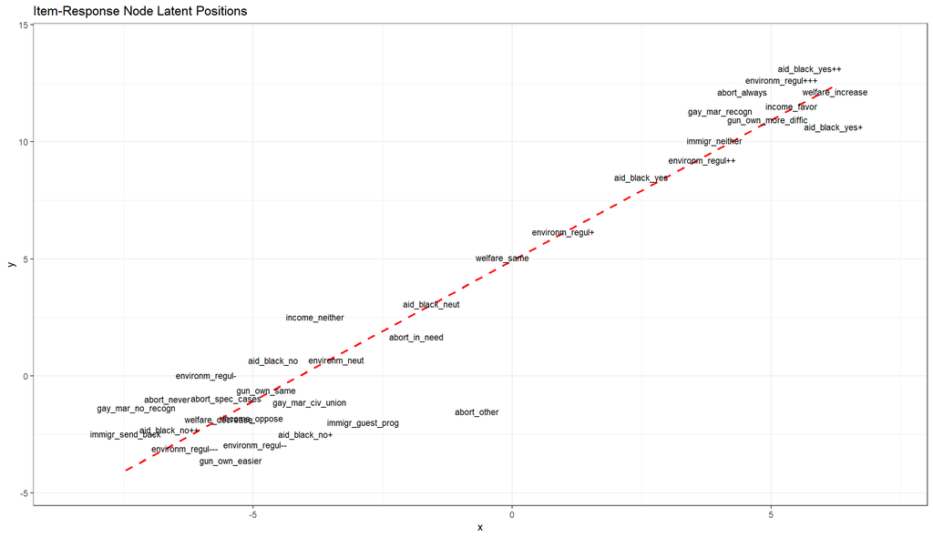

# 2.4 Coordinate rotation

- We use principle components analysis (PCA) to make graphical result more interpretable
- X-axis rotated s.t. it captures most of the variance within the attitude network
- We use orthogonal (non-distorting) rotation but different oblique rotations would theoretically be possible as well

# 2.4.1 Coordinate rotation using PCA

```r
## Performing PCA with the R-native "prcomp" function
res_in_layout_pca <- prcomp(res_in_layout[,1:2])$x
res_in_layout[1:2] <- res_in_layout_pca
```

# 2.4.1 Coordinate rotation using PCA - R example

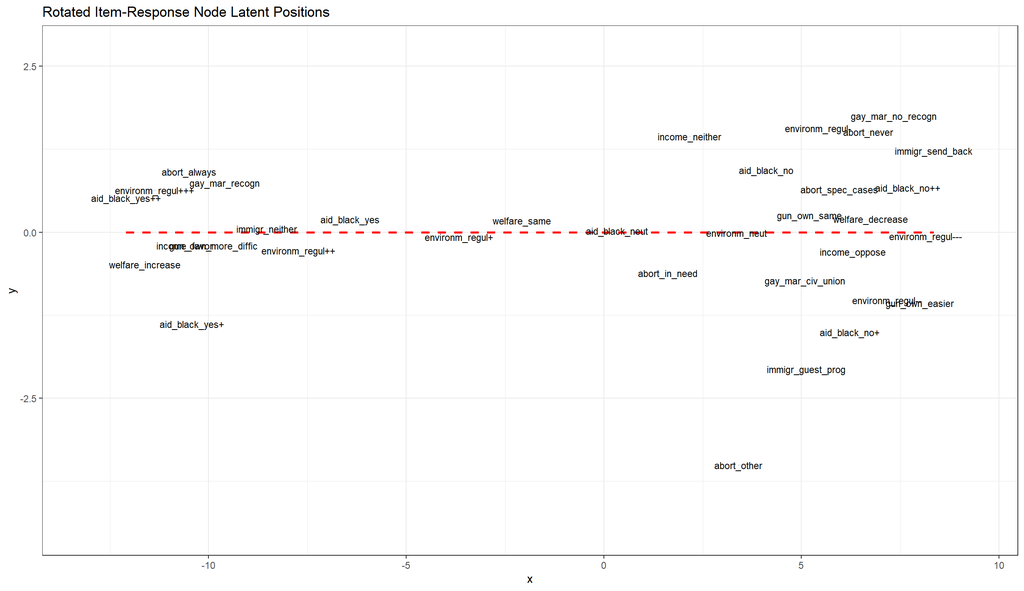

# 3 Visualization

- Using **qgraph-package** (optional: use PCA-rotated coordinates)
- Using **ggplot2**

# 3.1 Visualization with *qgraph*

```r
## qgraph package (Epskamp and Costantini et.al.)
res_in_qgraph <- qgraph::qgraph(res_in_cor, layout = "spring", maximum = 1,
                              vsize = 6, DoNotPlot = TRUE,
                              sampleSize = nrow(anes_nodes),
                              title = "Plot generated with qgraph",
                              mar = c(100,100,100,100), normalize = FALSE)

## Extracting edgelist to manually run F-R force directed algorithim
temp_edges <- cbind(res_in_qgraph$Edgelist$from, res_in_qgraph$Edgelist$to)

## Run FR using qgraph-supplied function
layout_fr <-  qgraph.layout.fruchtermanreingold(
  temp_edges, weights = res_in_qgraph$Edgelist$weight, vcount = nrow(temp_edges))

## Orthogonal rotation and re-scaling using PCA
layout_fr_pca <- princomp(layout_fr[1:nrow(res_in_cor), ])
layout_fr_pca$scores <- layout_fr_pca$scores/max(layout_fr_pca$scores)*10
layout_fr_pca$scores[, 1] <- -(layout_fr_pca$scores[, 1])

## Replace the orig. layout with PCA rotated & rescaled layout
res_in_qgraph$layout <- layout_fr_pca$scores
res_in_qgraph$layout.orig <- layout_fr_pca$scores
```

# 3.1.1 Visualization with *qgraph* - result

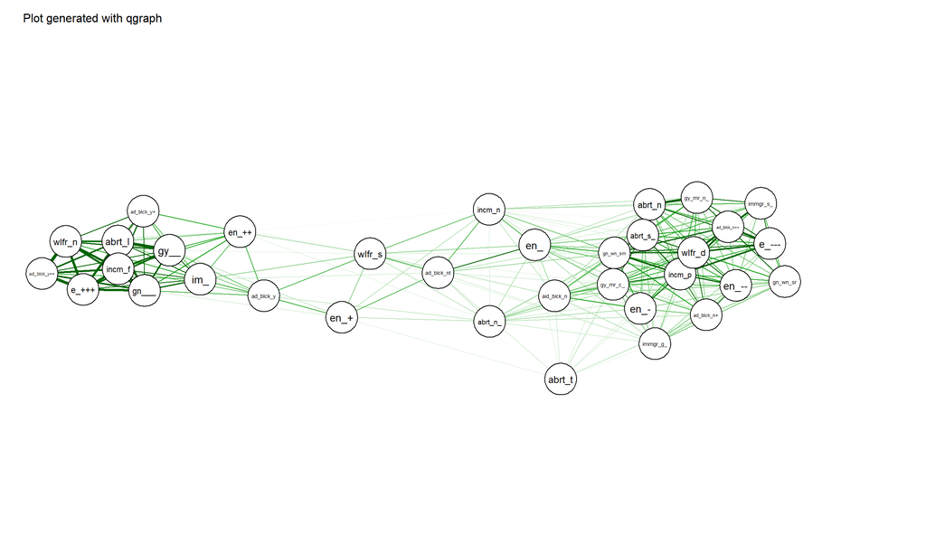

# 3.2 Visualization with *ggplot2*

1. Transforming igraph output to **ggplot** friendly data.frame
2. Use the *geom_curve()* layer for network visualization
3. Add node-level covariates or network statistics to enhance visualization
4. Take advantage of ggplot’s flexibility to take your plot to the next level

# 3.2.1 Visualization with *ggplot2* - prep work

```r
## First define an igraph object from the ResIn adjecency matrix
res_in_igraph <- igraph::graph_from_adjacency_matrix(
                          res_in_cor, weighted=TRUE,
                          mode="undirected", diag=FALSE)

## Create a ggplot-friendly data-frame using the igraph F-R algorithm:
res_in_layout  <- layout_with_fr(res_in_igraph)
res_in_layout <- princomp(res_in_layout)$scores %>% as.data.frame()

res_in_layout$node_names <- colnames(res_in_cor)
colnames(res_in_layout) <- c("x", "y", "from")

## Use igraph's basic plotting structure as scaffolding for edgelist:
g_temp <- igraph::as_data_frame(res_in_graph_igraph)

## We'll replace the igraph edgelist values with PCA-rotated solution
g_temp$from.x <- res_in_layout$x[match(g_temp$from, res_in_layout$from)]
g_temp$from.y <- res_in_layout$y[match(g_temp$from, res_in_layout$from)]
g_temp$to.x <- res_in_layout$x[match(g_temp$to, res_in_layout$from)]
g_temp$to.y <- res_in_layout$y[match(g_temp$to, res_in_layout$from)]

## Final plotting frame:
plotting_frame <- left_join(g_temp, res_in_layout, by = "from")
```

# 3.2.2 Visualization with *ggplot2* example data-frame

| from | to | weight | from.x | from.y | to.x | to.y | x | y |
| --- | --- | --- | --- | --- | --- | --- | --- | --- |
| abort_always | income_favor | 0.32 | -10.80 | -0.38 | -10.70 | 0.40 | -10.80 | -0.38 |
| abort_always | immigr_neither | 0.19 | -10.80 | -0.38 | -8.59 | 0.45 | -10.80 | -0.38 |
| abort_always | welfare_increase | 0.26 | -10.80 | -0.38 | -11.86 | -0.18 | -10.80 | -0.38 |
| abort_always | gay_mar_recogn | 0.44 | -10.80 | -0.38 | -9.75 | -0.24 | -10.80 | -0.38 |
| abort_always | environm_regul++ | 0.09 | -10.80 | -0.38 | -8.07 | -0.81 | -10.80 | -0.38 |
| abort_always | environm_regul+++ | 0.35 | -10.80 | -0.38 | -11.38 | 0.95 | -10.80 | -0.38 |
| abort_always | gun_own_more_diffic | 0.33 | -10.80 | -0.38 | -10.02 | 0.73 | -10.80 | -0.38 |
| abort_always | aid_black_yes | 0.07 | -10.80 | -0.38 | -6.58 | 0.08 | -10.80 | -0.38 |
| abort_always | aid_black_yes+ | 0.17 | -10.80 | -0.38 | -10.75 | -1.38 | -10.80 | -0.38 |
| abort_always | aid_black_yes++ | 0.25 | -10.80 | -0.38 | -12.16 | 0.90 | -10.80 | -0.38 |
| abort_in_need | income_neither | 0.02 | 1.66 | -0.72 | 2.25 | 1.31 | 1.66 | -0.72 |
| abort_in_need | income_oppose | 0.05 | 1.66 | -0.72 | 6.50 | -0.13 | 1.66 | -0.72 |
| abort_in_need | immigr_guest_prog | 0.03 | 1.66 | -0.72 | 5.42 | -2.09 | 1.66 | -0.72 |
| abort_in_need | immigr_neither | 0.00 | 1.66 | -0.72 | -8.59 | 0.45 | 1.66 | -0.72 |
| abort_in_need | welfare_decrease | 0.03 | 1.66 | -0.72 | 6.54 | 0.54 | 1.66 | -0.72 |

# 3.2.3 Visualization with *ggplot2* - basic plot

```r
ANES_net_fig <- ggplot() +
    geom_curve(data = plotting_frame, aes(x = from.x, xend = to.x, y = from.y,
                yend = to.y), curvature = 0, color = "grey") +
        ## geom_curve requires the x, xend, y and yend aesthetics to be able to plot the network edges
    geom_text(data = plotting_frame, aes(x = from.x, y = from.y, label = from), size = 3) +
    geom_text(data = plotting_frame, aes(x = to.x, y = to.y, label = to), size = 3) +
        ## Make sure to plot node labels both based on the to and from columns in the plotting frame!
    ggtitle("Belief Structure among ANES 2020 Respondents")+
    theme_bw()+
    expand_limits(x = c(min(plotting_frame$x-2), max(plotting_frame$x+2)),
                  y = c(min(plotting_frame$y-2), max(plotting_frame$y+2))) +
    theme(axis.text.x = element_blank(), axis.title.x = element_blank(),
          axis.text.y = element_blank(), axis.title.y = element_blank(),
          axis.ticks = element_blank(), panel.grid.major = element_blank(),
          panel.grid.minor = element_blank(), legend.position = "bottom",
          legend.text = element_blank(), plot.title = element_text(hjust = 0.5))
```

# 3.2.4 Visualization with *ggplot2* - basic plot

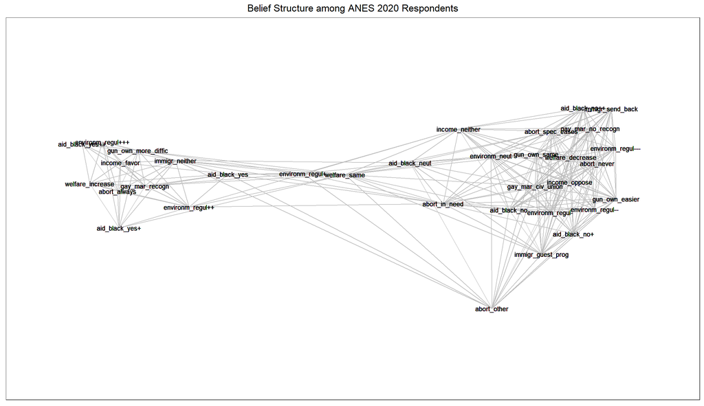

# 3.3.5 Visualization with *ggplot2* - more fancy plot

```r
## Calculating summary statistics based on select co-variates & stats; here we use Dem. & Rep. feelings thermometers
node_covars <- c("V201157", "V201156")

## We would like to extract the mean of each thermometer variable for the subset of respondents who selected each item response
node_costats <- c("mean", "mean")

covars_frame <- dplyr::select(anes_timeseries_2020, node_covars)
cov_stats <- as.data.frame(matrix(NA, nrow(res_in_layout), ncol(covars_frame)))

for(i in 1:nrow(res_in_layout)) {
  for(j in 1:ncol(covars_frame)) {
        cov_stats[i, j] <- do.call(node_costats[j], c(list(
          x = covars_frame[, j][df_dummies[, i] == 1], na.rm = TRUE)))
  }
}

colnames(cov_stats) <- paste(node_covars, node_costats, sep = "_")
cov_stats$node_label <- colnames(res_in_cor)

## We also calculate the level of affective polarization based on the Dem & Rep feelings thermometer scores
cov_stats$aff_pola <- abs(cov_stats$V201157_mean - cov_stats$V201156_mean)
res_in_layout_stats <- cbind(res_in_layout, cov_stats)

## Here, we integrate our node-level covariate statistics back into the original plotting frame
plotting_frame <- left_join(g_temp, res_in_layout_stats, by = "from")
```

# 3.3.7 Visualization with *ggplot2* - data-frame

| from | to | weight | from.x | from.y | to.x | to.y | x | y | D_mean_FT | R_mean_FT | node_label | aff_pola |
| --- | --- | --- | --- | --- | --- | --- | --- | --- | --- | --- | --- | --- |
| abort_always | income_favor | 0.32 | -10.80 | -0.38 | -10.70 | 0.40 | -10.80 | -0.38 | 28.22 | 58.32 | abort_always | 30.11 |
| abort_always | immigr_neither | 0.19 | -10.80 | -0.38 | -8.59 | 0.45 | -10.80 | -0.38 | 28.22 | 58.32 | abort_always | 30.11 |
| abort_always | welfare_increase | 0.26 | -10.80 | -0.38 | -11.86 | -0.18 | -10.80 | -0.38 | 28.22 | 58.32 | abort_always | 30.11 |
| abort_always | gay_mar_recogn | 0.44 | -10.80 | -0.38 | -9.75 | -0.24 | -10.80 | -0.38 | 28.22 | 58.32 | abort_always | 30.11 |
| abort_always | environm_regul++ | 0.09 | -10.80 | -0.38 | -8.07 | -0.81 | -10.80 | -0.38 | 28.22 | 58.32 | abort_always | 30.11 |
| abort_always | environm_regul+++ | 0.35 | -10.80 | -0.38 | -11.38 | 0.95 | -10.80 | -0.38 | 28.22 | 58.32 | abort_always | 30.11 |
| abort_always | gun_own_more_diffic | 0.33 | -10.80 | -0.38 | -10.02 | 0.73 | -10.80 | -0.38 | 28.22 | 58.32 | abort_always | 30.11 |
| abort_always | aid_black_yes | 0.07 | -10.80 | -0.38 | -6.58 | 0.08 | -10.80 | -0.38 | 28.22 | 58.32 | abort_always | 30.11 |
| abort_always | aid_black_yes+ | 0.17 | -10.80 | -0.38 | -10.75 | -1.38 | -10.80 | -0.38 | 28.22 | 58.32 | abort_always | 30.11 |
| abort_always | aid_black_yes++ | 0.25 | -10.80 | -0.38 | -12.16 | 0.90 | -10.80 | -0.38 | 28.22 | 58.32 | abort_always | 30.11 |
| abort_in_need | income_neither | 0.02 | 1.66 | -0.72 | 2.25 | 1.31 | 1.66 | -0.72 | 47.64 | 40.21 | abort_in_need | 7.43 |
| abort_in_need | income_oppose | 0.05 | 1.66 | -0.72 | 6.50 | -0.13 | 1.66 | -0.72 | 47.64 | 40.21 | abort_in_need | 7.43 |
| abort_in_need | immigr_guest_prog | 0.03 | 1.66 | -0.72 | 5.42 | -2.09 | 1.66 | -0.72 | 47.64 | 40.21 | abort_in_need | 7.43 |
| abort_in_need | immigr_neither | 0.00 | 1.66 | -0.72 | -8.59 | 0.45 | 1.66 | -0.72 | 47.64 | 40.21 | abort_in_need | 7.43 |
| abort_in_need | welfare_decrease | 0.03 | 1.66 | -0.72 | 6.54 | 0.54 | 1.66 | -0.72 | 47.64 | 40.21 | abort_in_need | 7.43 |

# 3.3.8 Visualization with *ggplot2* - more fancy plot

```r
p_load(ggdark)

ANES_net_fig <- ggplot() +
    geom_curve(data = plotting_frame, aes(x = from.x, xend = to.x, y = from.y,
                yend = to.y, size = weight^10), curvature = 0.15, color = "darkgrey", alpha = 0.4) +
                  ## Note that we use the size aesthetic to control the thickness of the graph edges
    geom_text(data = plotting_frame, aes(x = from.x, y = from.y, label = from, color = aff_pola), size = 6) +
    geom_text(data = plotting_frame, aes(x = to.x, y = to.y, label = to, color = aff_pola), size = 6) +
                  ## Make sure to plot node labels both based on the to and from columns in the plotting frame
    ggtitle("Belief Structure among ANES 2020 Respondents")+
    expand_limits(x = c(min(plotting_frame$x-1.5), max(plotting_frame$x+1.5)),
                  y = c(min(plotting_frame$y-1.5), max(plotting_frame$y+1.5))) +
    scale_color_continuous(name = "Intensity of Partisan Affective Polarization", high = "yellow", low = "blue")+
    scale_size_continuous(guide = "none")+
    dark_theme_gray()+
    theme(axis.text.x = element_blank(), axis.title.x = element_blank(),
          axis.text.y = element_blank(), axis.title.y = element_blank(),
          axis.ticks = element_blank(), panel.grid.major = element_blank(),
          panel.grid.minor = element_blank(), legend.position = "bottom",
          legend.text = element_blank(), plot.title = element_text(hjust = 0.5, size=18))
```

# 3.3.9 Visualization with *ggplot2* - more fancy plot

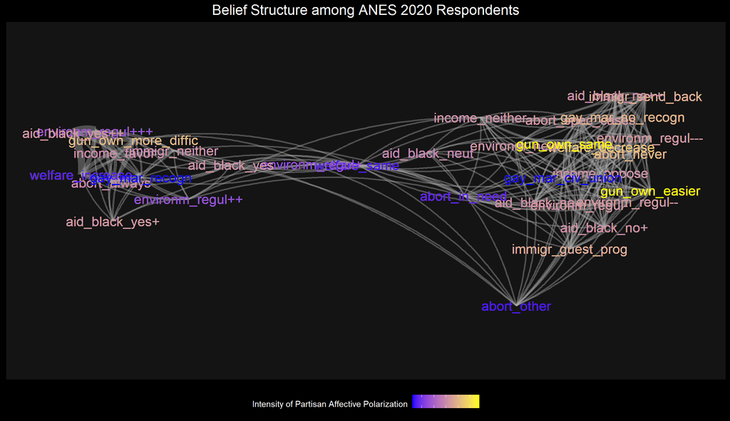

# 4. ResIn Function & Advanced Features

- **ResIN**: Base function designed for easy qgraph and igraph integration & elementary plotting options
- **ResIN_gen**: Advanced function able to automatically calculate co-variate, node-level, edge-level, and network-level statistics as well customization of various features and advanced plotting options
- Interactive advanced plotting features using **visNetwork**

# 4.1 ResIn base-function arguments

- **df**: A cleaned data-frame object
- **node_vars**: (Optional) Character string featuring the attitude node variables
- **output**: (Optional) Character string specifying the outcome objects. Can be either “qgraph” for qgraph object, “igraph” for igraph object or c(“qgraph”, “igraph”) to generate both objects. If NULL, only the ResIn adjacency matrix and a factor vector for item response groupings (“same_items”) are returned.
- **remove_negative**: (Optional) Should negative correlations be removed? Defaults to TRUE.
- **plot_graph**: Should qgraph or igraph objects objects automatically be plotted upon function execution? Defaults to TRUE.
- **qgraph_arglist**: (Optional) An arglist containing arguments passed down to the qgraph function. See qgraph package documentation for details.
- **igraph_arglist**: (Optional) An arglist containing arguments passed down to the *igraph::graph_from_adjacency_matrix* function. See igraph package documentation for details.

# 4.1.1 ResIn base-function returns

- **adj_matrix**: The $k*k$ ResIn adjacency matrix where $k$ is the sum of all unique item response options across all items
- **qgraph_obj**: A class “S3::igraph” list. Behaves just like any other graph object generated with *igraph*
- **igraph_obj**: A class “S3::qgraph” list. Behaves just like any other graph object generated with *qgraph*
- **same_items**: A character vector of length k grouping the ResIn nodes by the original items they pertain to.

# 4.1.2 ResIn base-function example 1: igraph object

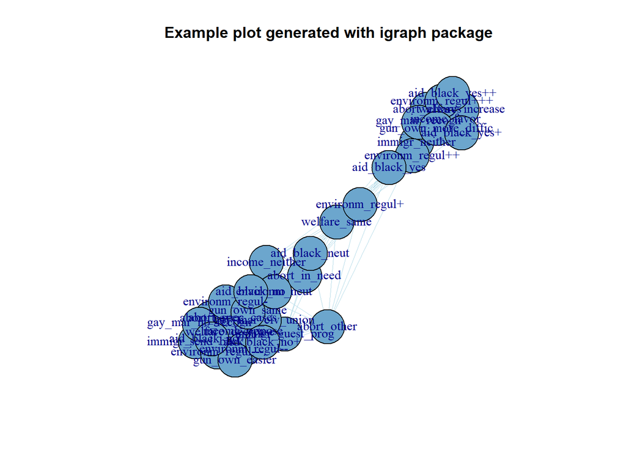

```r
test_run_1 <- ResIN(anes_nodes, node_vars = c("abort", "income", "immigr",
                    "welfare", "gay_mar", "environm", "gun_own", "aid_black"),
                   output = c("igraph"), plot_graph = TRUE,
                   plot_title = "Example plot generated with igraph package")
```

# 4.1.3 ResIn base-function example 1: Adjecency matrix

```r
kable(round(test_run_1$adj_matrix[1:10, 1:6], 2), format = "html", booktabs = TRUE)
```

|  | abort_always | abort_in_need | abort_never | abort_other | abort_spec_cases | income_favor |
| --- | --- | --- | --- | --- | --- | --- |
| abort_always | 0.00 | 0.00 | 0.00 | 0.00 | 0.00 | 0.32 |
| abort_in_need | 0.00 | 0.00 | 0.00 | 0.00 | 0.00 | 0.00 |
| abort_never | 0.00 | 0.00 | 0.00 | 0.00 | 0.00 | 0.00 |
| abort_other | 0.00 | 0.00 | 0.00 | 0.00 | 0.00 | 0.00 |
| abort_spec_cases | 0.00 | 0.00 | 0.00 | 0.00 | 0.00 | 0.00 |
| income_favor | 0.32 | 0.00 | 0.00 | 0.00 | 0.00 | 0.00 |
| income_neither | 0.00 | 0.02 | 0.05 | 0.00 | 0.02 | 0.00 |
| income_oppose | 0.00 | 0.05 | 0.13 | 0.02 | 0.20 | 0.00 |
| immigr_guest_prog | 0.00 | 0.03 | 0.01 | 0.01 | 0.07 | 0.00 |
| immigr_neither | 0.19 | 0.00 | 0.00 | 0.00 | 0.00 | 0.18 |

# 4.1.4 ResIn base-function example 2: qgraph object

```r
test_run_2 <- ResIN(anes_nodes,
                    node_vars = c("abort", "income", "welfare", "gay_mar",
                                  "environm", "gun_own", "aid_black"),
                    output = c("qgraph"), plot_graph = FALSE, same_item_groups = TRUE,
                    qgraph_arglist = list(layout = "spring", maximum = 1, vsize = 6,
                                          title = "Example plot generated with qgraph package",
                                          mar = c(2,2,2,1), DoNotPlot = TRUE, normalize = FALSE,
                                          theme = "Borkulo", shape = "diamond", pastel = TRUE,
                                          label.scale = FALSE, label.cex = 0.8, label.prop = 0.5,
                                          legend.cex = 0.6))
```

# 4.1.5 ResIn base-function example 2: qgraph plot

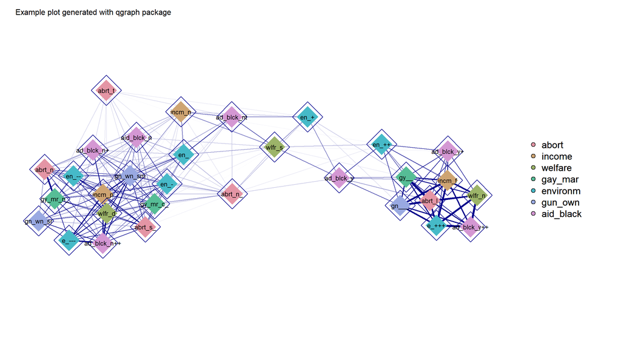

# 4.2 Advanced ResIn_gen features

- **cor_method**: Which correlation method should be used? Possible are “pearson”, “kendall”, “spearman”, and “auto”. The “auto” option calls the *qgraph::corr_auto* function which provides a fast implementation of the polychoric correlation coefficient for binary data. Defaults to “auto”.
- **weights**: Optionally specify a weights vector of length n to calculate weighted correlation coefficients using the *wCorr* method. Defalts to NULL.
- **method_wCorr**: If weights are used, which type of weighted correlation should be used. Options include “Pearson”, “Spearman”, “Polychoric”, and “Polyserial”. Defaults to “Polychoric”
- **EBICglasso**: Optionally further increase the sparseness of ResIn correlation matrix by performing Gaussian graphical lasso algorithim using the Extended Baysian Information Criterion. Method calls the *qgraph::EBICglasso* Useful for visualizing very large ResIn graphs although the algorithm might take a while to converge. Defaults to FALSE.
- **EBICglasso_arglist**: An arglist that can optionally be fed to the *qgraph::EBICglasso* function.
- **node_covars**: Optionally select a series of co-variates to obtain node-level statistics. For example the share of female or Republican respondents selecting a particular item response. Can provide useful contextual information for plotting. Defaults to NULL.
- **node_costats**: A character vector of the same length as *node_covars* detailing the summary statistic to be obtained from the co-variates on the basis of subsets of respondents who selected each item response. First element in *node_costats* corresponds to the summary statistic to be calculated from the first element in *node_covars*. Possible stats are “mean”, “median”, “mode”, “sd”, and “var”.
- **network_stats**: Should node level and network level structural descriptive statistics be obtained? If set to TRUE, the function obtains betweenness-, closeness-, and strength centrality, as well as expected influence values for each ResIn network node. At the graph level, the function calculates betweenness-, closeness-, strength- and expected influence centralization, as well as the graph average path length and the global clustering coefficient. Defaults to FALSE.

# 4.2.1 ResIn_gen advanced function returns

- **adj_matrix**: The k*k ResIn adjacency matrix where k are all unique item responses across all items
- **same_items**: A character vector of length k grouping the ResIn nodes by the original items they pertain to. Useful for grouped plotting of ResIn items
- **ggplot_frame**: A ggplot friendly edge-list dataframe. The dataframe has as many rows as ResIn network edges. Features plotting coordinates for all graph edges and nodes as well as node-level network statistics if called for by the main function.
- **outcome_frame**: A ggplot friendly node-list dataframe. The dataframe has as many rows as ResIn network nodes. Features plotting coordinates for all nodes as well as node-level network statistics if called for by the main function.
- **graph_structuration**: Named vector containing graph-level structuration statistics.
- **graph_centralization**: Named vector containing graph-level centralization statistics.

# 4.2.2 Advanced features - one European example

```r
## Importing ESS 2018 dataset and selecting all relevant variables
ESS_9 <- read.csv("ESS_9.csv")

ESS_9_n <- ESS_9 %>% dplyr::select(cntry, lrscale, gincdif, freehms, imsmetn, imdfetn, impcntr,
                                   ipstrgv, ipeqopt, impenv, pspwght)

## Sub-setting only Austrian respondents
ESS_9_at <- ESS_9_n[ESS_9_n$cntry=="AT", ]

## Using the advanced function to generate a plotable data-frame
ResIN_gen_AT <- ResIN_gen(ESS_9_at, node_vars =
                            c("lrscale", "gincdif", "freehms", "impcntr",
                              "ipstrgv", "ipeqopt", "impenv"),
                          weights = "pspwght", EBICglasso = TRUE, network_stats = TRUE)
```

# 4.2.3 Advanced features - plotting European example

```r
## ResIn_gen stores the ggplot-ready dataframe in an object called "ggplot_frame"
plotting_frame <- ResIN_gen_AT$ggplot_frame

## Here we order the plotting frame by the statistics we are using as a visual aesthetic.
  ## We'd like the most central nodes and edges to appear on top of the more peripheral nodes which is why we sort in ascending order.
plotting_frame <- plotting_frame[order(plotting_frame$Strength, decreasing = FALSE), ]

## Now we can plot the network using geom_curve!
ESS_net_fig <- ggplot() +
    geom_curve(data = plotting_frame, aes(x = from.x, xend = to.x, y = from.y,
                yend = to.y, size = weight^10, color = Strength), curvature = 0.2) +
                  ## Here, we specified edge size according to the correlation weight and color edges based on node strength centrality
    geom_text(data = plotting_frame, aes(x = from.x, y = from.y, label = from), size = 4.2, color = "white") +
    geom_text(data = plotting_frame, aes(x = to.x, y = to.y, label = to), size = 4.2, color = "white") +
    ggtitle("Belief System Structure among Austrian ESS 2018 Respondents")+
    theme_dark()+
    scale_color_continuous(name = "Node Strength Centrality (lowest to highest): ", high = "#132B43", low = "#56B1F7")+
    scale_size_continuous(guide = "none")+
    theme(axis.text.x = element_blank(), axis.title.x = element_blank(),
          axis.text.y = element_blank(), axis.title.y = element_blank(),
          axis.ticks = element_blank(), panel.grid.major = element_blank(),
          panel.grid.minor = element_blank(), legend.position = "bottom",
          legend.text = element_blank())
```

# 4.2.4 Advanced features - plotting European example

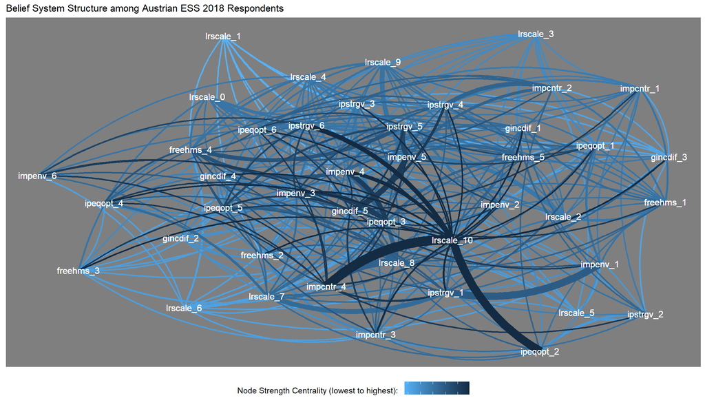

# 4.3 Interactive visualization with visNetwork package

- Here, we rely on the **visNetwork** package to provide a java-script based, HTML implementation for visualizing the ResIn network.
- **visNetwork** models a force-directed algorithm in real time; the package allows for displaying connected edged and node-level statistics upon mouse hovering.

# 4.3.1 ANES 2020 Interactive Plot

```r
## Very simple example employing the ResIn_gen function to ANES data:
ResIN_gen_ANES <- ResIN_gen(anes_nodes, EBICglasso = TRUE, network_stats = TRUE)

## Here we need to do just a little bit of prep-work for the visNetwork package
    ## At the node level, visNetwork minimally needs a unique id column.
      ## Additional columns such as "label", "group", and "title" are optional but very useful for interactive plotting
ResIN_gen_ANES$outcome_frame$id <- ResIN_gen_ANES$outcome_frame$node_names
ResIN_gen_ANES$outcome_frame$label <- ResIN_gen_ANES$outcome_frame$node_names
ResIN_gen_ANES$outcome_frame$group <- ResIN_gen_ANES$same_items

    ## The "title" column allows for a flexible HTML pop-up window as part of the integration.
      ## Here, we customize this window with network descriptive statistics:
ResIN_gen_ANES$outcome_frame$title <- paste0("<center> <strong>", ResIN_gen_ANES$outcome_frame$label, "</strong> </center> <br>",
                                          "Strength centrality: ", round(ResIN_gen_ANES$outcome_frame$Strength, 2), "<br>",
                                          "Betweeness centrality: ", ResIN_gen_ANES$outcome_frame$Betweenness, "<br>",
                                          "Closeness centrality: ", round(ResIN_gen_ANES$outcome_frame$Closeness, 3) , "<br>",
                                          "Expected influence: ", round(ResIN_gen_ANES$outcome_frame$ExpectedInfluence, 2), "<br>")

## At the edge-level, visNetwork minimally requires a "from" and "to" vector.
    ## Here we additionally specify the edge weights as "value" collumn.
ResIN_gen_ANES$ggplot_frame$value <- ResIN_gen_ANES$ggplot_frame$weight

## Note how we keep the visualization as sparse as possible by specifying a 0-degree nearest neighbor highlighting option:
ResIN_gen_ANES_plot <- visNetwork(ResIN_gen_ANES$outcome_frame, ResIN_gen_ANES$ggplot_frame,
                                  main = "Interactive ANES 2020 Belief System Visualization") %>%
  visOptions(highlightNearest = list(enabled = TRUE, degree = 0, hover = TRUE)) %>%
  visNodes(size = 24) %>% visInteraction(hideEdgesOnDrag = TRUE)
```

# 4.3.2 ANES 2020 Interactive Plot

[interactive chart not shown]